# yeg_opioid_report

Author

Mike Zhang

# Introduction

The implementation of supervised consumption sites (SCS) has been a contentious and heavily politicized public health topic in Alberta over the past few years. With the Alberta government having already closed some SCSs within the province and planning further closures in the near future, this project examines the association between SCS implementation and drug-related death rates in two major Alberta cities, Edmonton and Calgary, using segmented linear regression on time series data of opioid and all-substance death rates per 100,000 population. All data were scraped from the Alberta Substance Use Surveillance System and span January 2016 to March 2026. The main findings complicate a simple narrative because no statistically significant effect of SCS implementation was found in Calgary, for either opioid or all-substance death rates. In Edmonton, however, both opioid and all-substance death rates rose significantly faster following SCS implementation relative to control zones, and the near-identical effect across both outcomes suggests this reflects factors specific to Edmonton during this period rather than a mechanism attributable to SCS itself.

# Background

Supervised consumption sites (SCS) are health facilities where individuals can use pre-obtained drugs under the observation of trained staff, who can intervene with oxygen or naloxone if an overdose occurs. Naloxone specifically reverses opioid overdoses by blocking opioid receptors. It has no equivalent mechanism for cocaine, methamphetamine, alcohol, or most other substances. This mechanism matters for interpreting this project’s findings, discussed further below.

Alberta’s first SCS opened at Calgary’s Sheldon M. Chumir Health Centre in October 2017, followed shortly after by sites in Edmonton (Boyle Street Community Services in March 2018, George Spady Centre in April 2018, and Boyle McCauley Health Centre in November 2018) and the Royal Alexandra Hospital’s in-patient program. Over the following two years, sites also opened in several other Alberta cities: Lethbridge’s ARCHES site opened February 28, 2018 (closed by the provincial government in 2020, later replaced by a separate site at the Lethbridge Shelter), Red Deer opened a site around September 2018 (closed March 2025), and Grande Prairie’s mobile site opened March 11, 2019 and remains in operation. Lethbridge, Red Deer, and Grande Prairie fall within Alberta’s South, Central, and North health zones respectively — the same three zones used as comparison groups in this analysis, a point revisited in the Methods section.

SCS implementation has remained politically contentious in Alberta since these initial openings, with debate centered around concerns about crime, social disorder, and needle debris in surrounding neighbourhoods, weighed against harm-reduction outcomes such as overdose reversals and reduced disease transmission. Under the current provincial government, policy has shifted decisively toward a “recovery-oriented” model emphasizing treatment and detox services over harm reduction. This shift has translated into concrete closures: the Royal Alexandra Hospital site in Edmonton closed in December 2025, and in March 2026 the government announced the closure of the Calgary Chumir site and the Lethbridge site, both effective June 30, 2026 — leaving only two sites in Edmonton and the Grande Prairie mobile site remaining in the province. The government has cited a report from the Canadian Centre of Recovery Excellence, a Crown corporation it funds, showing no increase in mortality following the Red Deer site’s 2025 closure; critics have challenged both the report’s independence and its conclusions, and some have pointed to rising drug poisoning deaths in Lethbridge following the 2020 closure of the ARCHES site as evidence of harm.

The broader evidence base on SCS effectiveness is itself mixed. International research, most notably on Vancouver’s Insite facility, has generally reported reductions in overdose mortality and safer injection practices in surrounding areas. Evidence specific to Alberta and other Canadian jurisdictions is comparatively limited and contested, with government-commissioned reviews and independent research sometimes reaching different conclusions. Given the scale of the closures currently underway and the province’s stated intention to move away from this model entirely, a locally-scoped, methodologically rigorous evaluation of SCS impact in Alberta’s two largest cities is timely.

# Method

## Data

All the data analyzed were scraped from Alberta Substance Use Surveillance System (ASUSS)‘s SAS VA dashboard under its “Acute substance deaths overview” tab using Google Chrome Developer Tools’ Network tab to locate and download the underlying CSV export files. The monthly rates of drug poisoning deaths per 100,000 person years of all five AHS zones ranged from January 2016 to March 2026. Death rates of both any opioid and any substance were extracted as outcome variables for specificity check later. Among the zones, Edmonton and Calgary zones were modeled as treatment zones, while the other three (Central, North, South) were treated as control zones. For intervention starting dates, March 1st 2018 and October 1st 2017 were chosen for Edmonton and Calgary zones, respectively, because these were the months where each zone’s first SCS opened, and no denominator information was provided in its accompanying documentation.

## Study Design

Controlled interrupted time series (ITS) was selected for this project as it fits our scenario where a known-date intervention with a comparison group is available. Since SCS intervention dates were different for Edmonton and Calgary zones, they were modeled separately instead of pooled, which would force one shared date across both treated zones and misrepresent Calgary’s and Edmonton’s actual staggered timing. Notably, other three zones that served as the control group also opened and closed their own SCS sites over the years, so the analysis is more like a staggered-rollout comparison rather than treated-vs-never-treated.

## Model Specification

The final segmented regression formula is `rate ~ time + zone + intervention + time_after + covid + covid_time` where `rate` represents drug-related death rates per 100,000 person-years, `time` represents months passed since the earliest date of the data, `zone` represents AHS zones, a binary `intervention` variable indicates whether SCS was in effect or not, `time_after` serves as months passed since the intervention dates (0 before the intervention, and for control zones throughout), another binary `covid` variable indicates whether COVID-19’s lockdown, arbitrarily set to March 1st 2020, has happened, and `covid_time` represents months elapsed since COVID-19.

COVID-19 was modeled with both a level shift (`covid`) and a slope change (`covid_time`) rather than a level shift alone. This decision followed a specific diagnostic sequence where a formal linearity check (adding a quadratic term to `time_after` and testing it via likelihood ratio test) found significant curvature in the post-intervention segment for both Edmonton and Calgary. Visual inspection suggested this curvature coincided with the onset of COVID-19 rather than reflecting a genuine nonlinear SCS effect. To test this, `covid_time` was added to allow COVID-19 its own slope, separate from `time_after`. This resolved the issue since once `covid_time` was included, the quadratic term was no longer statistically significant, confirming that the apparent curvature was attributable to COVID-19’s distinct trajectory rather than non-linearity in the SCS effect itself.

## Auto-correlation

To be able to run segmented linear regression models, autocorrelation among data points at different dates needed to be corrected. An Ordinary Least Squares model without correction would distort the standard errors of parameter coefficients, leading to unreliable significance tests, even though the coefficient estimates themselves would remain unbiased. Generalized Least Squares (GLS) models were utilized over other alternatives, such as Prais-Winsten and Newey-West/HAC, because the data had a panel structure with multiple zones where zone-specific correction was needed. GLS was also favored over Generalized Estimating Equations (GEE), a comparable panel-data alternative, because GLS’s likelihood-based framework allowed the autocorrelation correction to be formally tested against a plain OLS model rather than simply assumed. The argument `method = "ML"` was included in `gls()` to fit AR(1)-corrected GLS models on a scale comparable to OLS models, and the two were compared using `anova()`, which returned statistically significant results for both treatment zones, justifying the AR(1) correction. All final models were run with `method = "REML"` for reporting.

## Assumption Checks

### Parallel Pre-trends

GLS models incorporating AR(1) correction using the formula `rate ~ time * zone` were run on each zone’s pre-intervention period, bounded by that treated zone’s own intervention date (`2017-10-01` for Calgary zone and `2018-03-01` for Edmonton zone). The results showed non-significant interaction terms for both Calgary and Edmonton against all three comparison zones, supporting the parallel pre-trends assumption.

## Sensitivity and Specificity Analyses

### Specificity Check

A specificity check was conducted by swapping the original outcome variable (any opioid death rates) for any-substance death rates. This tested mechanistic specificity to opioids, given SCS’s naloxone-based mechanism, which has no plausible pathway to affect non-opioid deaths. Results were nearly identical to the baseline AR(1) models, particularly for Edmonton, suggesting a zone-wide confound rather than an SCS-specific effect.

## Software

All analyses and visualizations were performed on R version 4.6.1. Packages utilized include `tidyverse` for general data manipulation and visualization (`ggplot2`), `lubridate` for date variables, and `nlme` for GLS modeling.

# Results

## Primary Model Results

Table 1: Segmented linear regression estimates for the effect of supervised consumption site (SCS) implementation on opioid-related death rates in Edmonton, with North, Central, and South zones as comparison groups (Central zone serves as the reference category).

| **Variable** | **Beta** | **95% CI** | **p-value** |
| --- | --- | --- | --- |
| (Intercept) | 9.6 | 1.7, 18 | 0.018 |
| Overall time passed | 0.10 | -0.12, 0.33 | 0.4 |
| Edmonton zone | 4.3 | -6.2, 15 | 0.4 |
| North zone | -1.3 | -7.4, 4.8 | 0.7 |
| South zone | 8.5 | 2.4, 15 | 0.007 |
| Immediate change at SCS opening | -3.9 | -17, 8.9 | 0.6 |
| Time passed since intervention | 0.28 | 0.09, 0.46 | 0.004 |
| COVID-19 | 18 | 11, 25 | <0.001 |
| Time passed since COVID-19 | -0.34 | -0.61, -0.06 | 0.019 |

Abbreviation: CI = Confidence Interval

Table 2: Segmented linear regression estimates for the effect of supervised consumption site (SCS) implementation on opioid-related death rates in Calgary, with North, Central, and South zones as comparison groups (Central zone serves as the reference category).

| **Variable** | **Beta** | **95% CI** | **p-value** |
| --- | --- | --- | --- |
| (Intercept) | 9.6 | 1.4, 18 | 0.022 |
| Overall time passed | 0.12 | -0.11, 0.35 | 0.3 |
| Calgary zone | 3.6 | -8.0, 15 | 0.5 |
| North zone | -1.3 | -7.7, 5.1 | 0.7 |
| South zone | 8.4 | 2.0, 15 | 0.010 |
| Immediate change at SCS opening | 3.8 | -9.3, 17 | 0.6 |
| Time passed since intervention | -0.10 | -0.28, 0.07 | 0.3 |
| COVID-19 | 16 | 9.1, 23 | <0.001 |
| Time passed since COVID-19 | -0.33 | -0.61, -0.04 | 0.026 |

Abbreviation: CI = Confidence Interval

According to the primary model results, Calgary showed no statistically significant SCS effect on opioid death rates — neither the immediate level shift at SCS opening nor the change in trend afterward reached significance (p = 0.6 and p = 0.3, respectively). Edmonton, by contrast, showed a statistically significant increase in the trend following SCS implementation (p = 0.004), indicating opioid death rates rose faster than expected relative to comparison zones after the SCS opened, though the immediate level shift itself was not significant.

COVID-19, modeled separately from the SCS effect, showed a significant positive immediate level shift in both zones (p < 0.001 for both), alongside a significant negative change in trend afterward (Edmonton: p = 0.019; Calgary: p = 0.026) — consistent with an initial spike in death rates at pandemic onset followed by a gradual moderation in the growth rate over time.

## Trajectory Visualizations

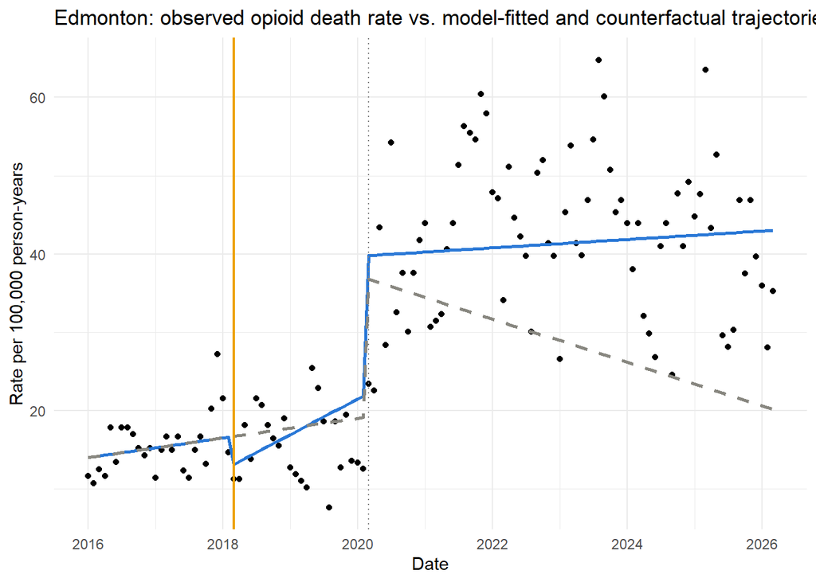

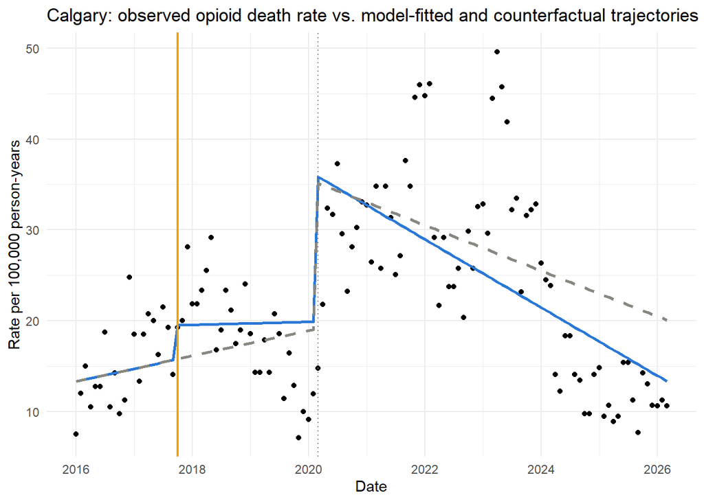

## Specificity Check

Table 3: Comparison of the estimated trend change (`time_after`) across opioid and any-substance outcomes, by zone.

| **Characteristic** | **Calgary: Opioid** **Beta** | **Calgary: Opioid** **95% CI** | **Calgary: Opioid** **p-value** | **Calgary: Any Substance** **Beta** | **Calgary: Any Substance** **95% CI** | **Calgary: Any Substance** **p-value** | **Edmonton: Opioid** **Beta** | **Edmonton: Opioid** **95% CI** | **Edmonton: Opioid** **p-value** | **Edmonton: Any Substance** **Beta** | **Edmonton: Any Substance** **95% CI** | **Edmonton: Any Substance** **p-value** |
| --- | --- | --- | --- | --- | --- | --- | --- | --- | --- | --- | --- | --- |
| Time passed since intervention | -0.10 | -0.28, 0.07 | 0.3 | -0.14 | -0.31, 0.04 | 0.14 | 0.28 | 0.09, 0.46 | 0.004 | 0.27 | 0.09, 0.46 | 0.004 |

Abbreviation: CI = Confidence Interval

The specificity check compared the estimated post-intervention trend change (`time_after`) between opioid-specific and any-substance death rates for each zone, testing whether the effect observed for Edmonton was specific to opioid, as would be expected if it reflected the SCS’s naloxone-based mechanism, or reflected a broader, zone-wide pattern. For Edmonton, the two coefficients were nearly identical (opioid: β = 0.28, p = 0.004; any-substance: β = 0.27, p = 0.004), with overlapping confidence intervals and matching significance. Since naloxone has no plausible mechanism for affecting non-opioid deaths, this near-equivalence across mechanistically distinct outcomes suggests Edmonton’s finding more likely reflects a broader confound specific to the zone during this period, rather than an effect attributable to the SCS itself. Calgary showed a similarly consistent pattern across both outcomes (opioid: β = -0.10, p = 0.3; any-substance: β = -0.14, p = 0.14), though neither reached statistical significance in either case.

## Sensitivity Analysis

Table 4: Comparison of the estimated trend change (`time_after`) across primary models, South-zone-excluded models, and no-control models

| **Characteristic** | **Calgary Opioid (Controlled model)** **Beta** | **Calgary Opioid (Controlled model)** **95% CI** | **Calgary Opioid (Controlled model)** **p-value** | **Calgary Opioid Excluding South** **Beta** | **Calgary Opioid Excluding South** **95% CI** | **Calgary Opioid Excluding South** **p-value** | **Calgary Opioid (Single-zone, no controls)** **Beta** | **Calgary Opioid (Single-zone, no controls)** **95% CI** | **Calgary Opioid (Single-zone, no controls)** **p-value** | **Edmonton Opioid (Controlled model)** **Beta** | **Edmonton Opioid (Controlled model)** **95% CI** | **Edmonton Opioid (Controlled model)** **p-value** | **Edmonton Opioid Excluding South** **Beta** | **Edmonton Opioid Excluding South** **95% CI** | **Edmonton Opioid Excluding South** **p-value** | **Edmonton Opioid (Single-zone, no controls)** **Beta** | **Edmonton Opioid (Single-zone, no controls)** **95% CI** | **Edmonton Opioid (Single-zone, no controls)** **p-value** |
| --- | --- | --- | --- | --- | --- | --- | --- | --- | --- | --- | --- | --- | --- | --- | --- | --- | --- | --- |
| Time passed since intervention | -0.10 | -0.28, 0.07 | 0.3 | -0.28 | -2.0, 1.5 | 0.8 | -0.11 | -0.19, -0.02 | 0.015 | 0.28 | 0.09, 0.46 | 0.004 | 0.27 | 0.17, 0.36 | <0.001 | -0.06 | -1.1, 0.99 | >0.9 |

Abbreviation: CI = Confidence Interval

# Discussions

This study set out to examine the association between supervised consumption site (SCS) implementation and drug-related death rates in Edmonton and Calgary, using a controlled interrupted time series design. The results do not support a straightforward “SCS reduced deaths” or “SCS increased deaths” narrative in either city. Calgary showed no reliable evidence of an effect in either direction. Edmonton showed a statistically significant increase in the post-intervention death rate trend, robust across most specifications tested. but the balance of evidence suggests this finding more likely reflects a broader, zone-specific confound than a causal effect of the SCS itself.

## Interpreting Edmonton’s finding

The specificity check is the most informative piece of evidence bearing on this question. If the SCS were driving Edmonton’s rising death rate through its actual harm-reduction mechanism, namingly supervised injection with naloxone available for opioid overdose reversal, the effect should be more prominent for opioid-specific deaths than for any-substance-related deaths, since naloxone has no plausible pathway to affect deaths from cocaine, methamphetamine, alcohol, or other non-opioid substances. Instead, the estimated trend change was nearly identical across both outcomes. This pattern is difficult to reconcile with a genuine SCS-specific mechanism and points instead toward something affecting substance-related mortality in Edmonton more broadly during this period that just happened to overlap with the SCS opening.

Several such factors are plausible, though this analysis cannot distinguish between them. A shift in the toxicity or composition of Edmonton’s drug supply, changes in housing or shelter capacity, shifts in policing practices around drug use, or other concurrent social or policy changes specific to Edmonton during this period could each independently explain a broad-based rise in substance-related mortality. None of these are captured in the model, and identifying the true driver would require additional data beyond the scope of this analysis. Additional information such as drug supply toxicity trends and site-level utilization data wouldn’t been helpful, but neither of which would require significantly more workload for a single-person project.

It is also worth noting that Edmonton’s finding held up not only across the specificity check but also under South-exclusion, and only failed to replicate under the uncontrolled single-zone specification, an expected result attributable to that model’s structural inability to separate Edmonton’s background trend from any SCS-related change rather than to the underlying finding being an artifact of the primary model’s design. Taken together, this is a genuinely robust empirical pattern, but the real causes of the pattern remains unresolved.

## Situating these findings in the broader policy debate

These results arrive at a consequential moment in Alberta’s SCS policy. As outlined in the Background section, the provincial government has moved decisively toward closing SCS facilities across the province, including the Calgary site examined in this analysis, citing a recovery-oriented treatment model as the preferred path forward. Neither this study’s findings nor the broader research record straightforwardly support the strong claims made by either side of this debate. This analysis found no evidence that Calgary’s SCS reduced opioid deaths, a finding that offers no support to arguments for the site’s protective value on the specific metric examined here. At the same time, Edmonton’s finding, while real, cannot be attributed to the SCS itself with any confidence given the specificity check’s results. Consequently, this study does not support claims that Edmonton’s SCS sites caused increased opioid mortality, either. The more important take-away from this study is that, if anything, is that relevant policy decisions should be informed by evidence considerably more comprehensive than a single zone-level time series analysis. Site utilization data, overdose reversal counts, and broader public health surveillance not captured in provincial death rate statistics alone, should also be integrated in future studies if possible.

## Limitations

Several limitations bear directly on how these findings should be interpreted. Most significantly, the three comparison zones used in this analysis were not completely untreated as Lethbridge (South), Red Deer (Central), and Grande Prairie (North) each opened their own SCS at different points during the study period, with Lethbridge’s opening occurring within weeks of Edmonton’s. This means the “control” condition in this design is more accurately characterized as a staggered rollout comparison than a true treated-versus-untreated design, and any real effects of these other sites could bias the estimated effects for Edmonton and Calgary in either direction.

The death rate denominators used in this analysis were pre-calculated by ASUSS, and the underlying population estimation methodology was not documented in the source data. Changes in that methodology over the ten-year study period cannot be ruled out as a source of variation in the rate series. The primary models also showed right-skewed residuals, most plausibly attributable to the inherent instability of rate estimates built on small monthly death counts in lower-population zones. A log-transformation attempted to address this introduced a different distortion and was not adopted, leaving this skew as an unresolved limitation of the reported models.

Finally, this study cannot rule out reverse causality in SCS site placement. Sites may have been sited in response to pre-existing or anticipated mortality trends rather than independently of them. Nor can it rule out spillover effects, such as individuals from comparison zones traveling to treated zones to access SCS services, which would bias comparisons in the opposite direction from contamination by comparison-zone sites.

## Future directions

A more definitive account of Edmonton’s finding would require data this study did not tap into: site-level utilization and overdose reversal records, drug supply toxicity surveillance, and comparable data from other Canadian or international jurisdictions with SCS implementation to test whether similar broad-based mortality increases have been observed elsewhere in association with site openings. Incorporating Red Deer’s site closure as an additional modeled break point, and extending the analysis to Alberta’s other SCS cities, would also help determine whether the pattern observed in Edmonton is unique to that city or reflects a more general dynamic across Alberta’s SCS roll-out.

# Conclusion

This study examined the association between supervised consumption site (SCS) implementation and drug-related death rates in Edmonton and Calgary using a controlled interrupted time series design, addressing a question of direct relevance to Alberta’s ongoing SCS policy debate. Calgary showed no reliable evidence of an SCS effect on opioid or all-substance death rates in either direction, a result that held consistently across the primary model and specificity check. Edmonton showed a statistically significant increase in the post-intervention death rate trend that proved robust across most specifications tested, including a specificity check comparing opioid-specific and all-substance outcomes. That specificity check, however, found the effect nearly identical across both outcomes despite SCS having no plausible mechanism to influence non-opioid deaths. It means that the finding more likely reflects a broader confound specific to Edmonton during this period than a causal effect of the SCS itself.

Taken together, these results do not support a simple narrative in either direction. They offer no evidence that Calgary’s SCS reduced opioid deaths, but neither do they support the claim that Edmonton’s SCS sites caused increased opioid mortality. The robust pattern observed in Edmonton remains real, but its cause is unresolved by this analysis. This underscores a broader point relevant to the current policy debate that single-outcome, city-level analyses of this kind can identify genuine patterns worth taking seriously, but establishing their cause requires evidence this study did not have access to, including site-level utilization data and drug supply surveillance. Given the scale of SCS closures currently underway in Alberta, decisions of this consequence warrant an evidence base considerably more comprehensive than what any single study, including this one, can provide.

# Appendix: Diagnostic Plots

## A.1 Normality of Residuals

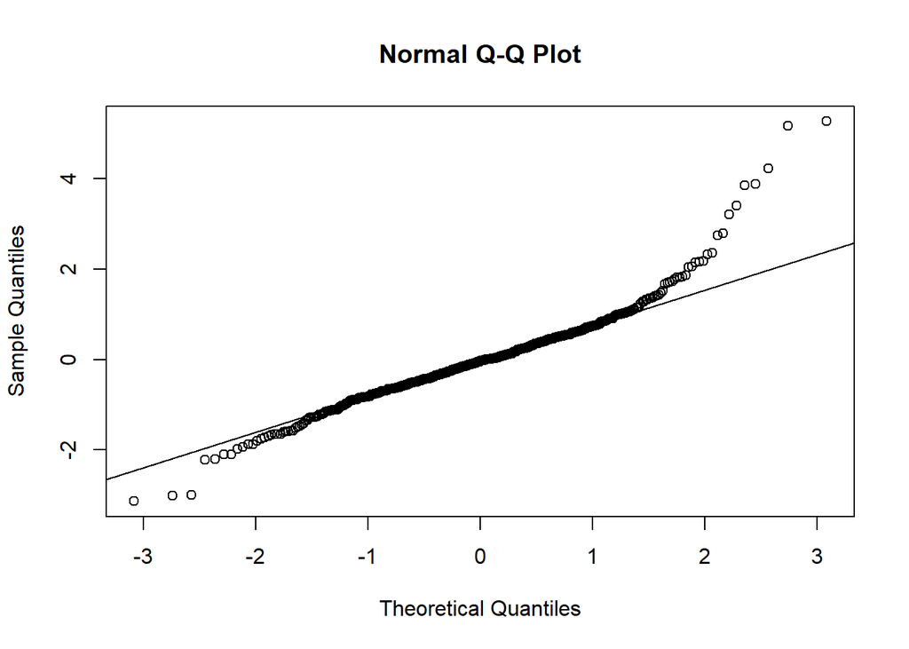

Figure 3: QQ plot of Edmonton zone’s primary models

[figure not shown]

Figure 4: QQ plot of Calgary zone’s primary model

## A.2 Residual Autocorrelation (ACF Plots)

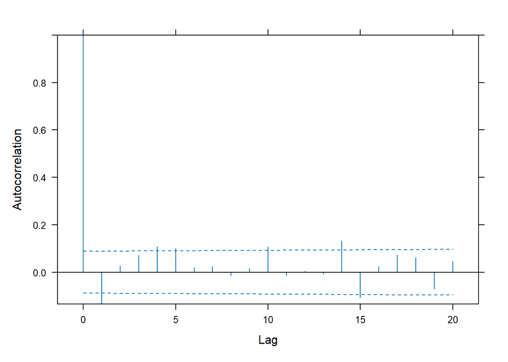

Figure 5: ACF plot of Calgary zone’s primary model

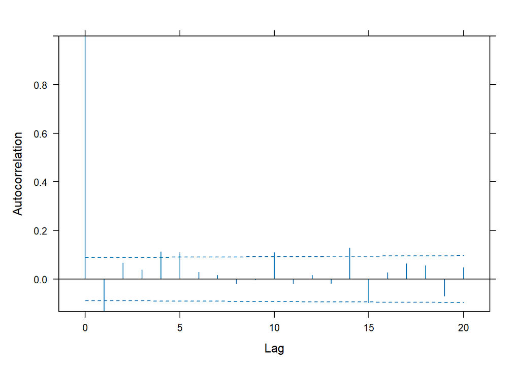

Figure 6: ACF plot of Edmonton zone’s primary model